# ILT Data Explorer v0.2 (16/01/2023) - Manual

O ILT Data Explorer é usado para criar conjuntos de dados baseado em rotulações feitas usando o ILT (antigo IAT).

Nesta ferramenta, é possível selecionar um conjunto de *batches* e de classes, e gera-se um conjunto de dados contendo as imagens destes *batches* separados por pastas, onde cada pasta representa uma classe diferente.

## Versões

- Versão 0.2 (16/01/2023)
  - O programa pede a confirmação do usuário antes de criar um conjunto de dados.
  - Adicionada a opção de adicionar imagens a um conjunto de dados criado anteriormente.
  - Os nomes dos conjuntos de dados já existentes são mostrados ao usuário quando o campo de texto está em branco.
- Versão 0.1 (13/01/2023)
  - Ferramenta criada

## Instruções de execução

1. Abrir um terminal na pasta IAT.
2. Para baixar ou atualizar o arquivo `data_explorer.py` para a última versão, digitar no terminal:
   - `git pull`
3. Ativar o `conda`, digitando no terminal:
   - `conda activate iat`
4. Rodar a ferramenta, digitando no terminal:
   - `python data_explorer.py`
5. A ferramenta deverá ser aberta automaticamente no navegador de *internet* padrão.
   - Se a ferramenta não abrir automaticamente, é possível abrí-la manualmente digitando o endereço `http://127.0.0.1:8030/` no navegador.
6. Para encerrar a ferramenta, apertar Ctrl+C no terminal.

## Interface

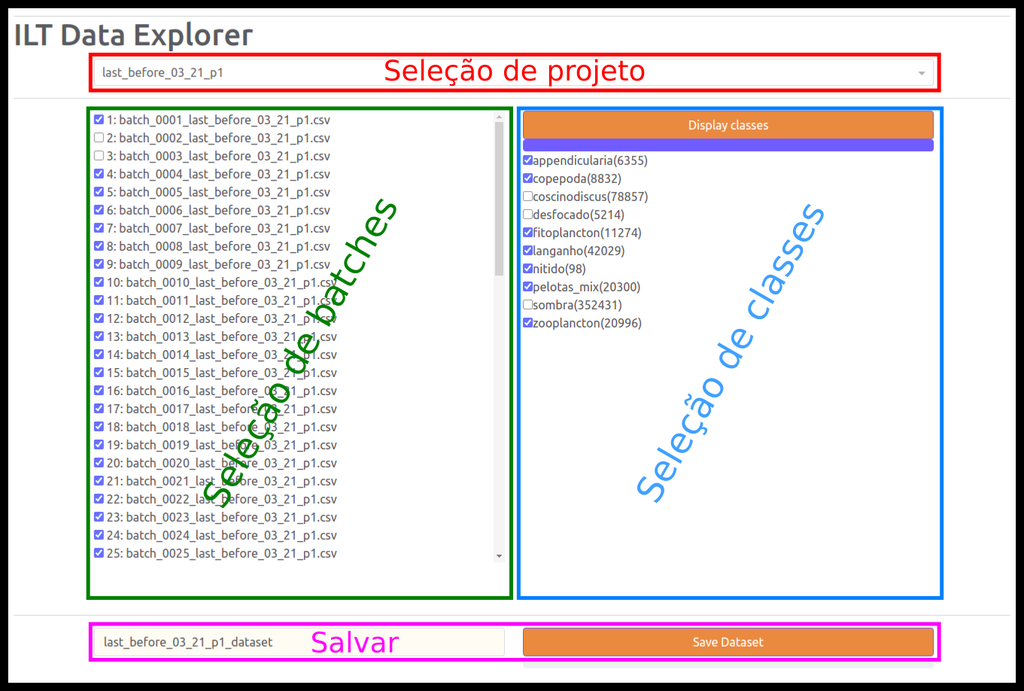

## Usando a ferramenta

O fluxo de execução da ferramenta segue os seguintes passos:

1. Seleção de projeto:
   - Selecionar um projeto do ILT.
2. Seleção de *batches*:
   - Marcar de quais *batches* as imagens serão exportadas.
3. Seleção de classes:
   - Uma vez que os *batches* de interesse forem marcados, apertar o botão "*Display classes*", para mostrar a distribuição de classes das imagens dos *batches* marcados.
     - Nota: esta operação pode levar um tempo, dependendo do número de *batches* marcados. A barra de progresso abaixo do botão indica o andamento da operação.
   - Selecionar quais classes serão exportadas na criação do conjunto de dados.
4. Salvar:
   - Digitar no campo de texto um nome para o conjunto de dados. Se o nome não existir, um conjunto de dados novo será criado. Senão, as imagens serão adicionadas ao conjunto já existente.
     - Nota 1: recomenda-se usar *underline* (_) ao invés de espaços na hora de nomear o conjunto de dados.
     - Nota 2: é possível ver a lista de conjuntos de dados já existentes ao apagar o campo de texto ou digitar parte do nome de um conjunto existente (Obs: a lista é carregada ao abrir a ferramenta. Para aparecer o nome de um conjunto recém-criado, é necessário fechar (Ctrl + C) e abrir a ferramenta novamente).
   - Apertar o botão "*Save Dataset*".
   - Se tudo estiver correto, confirmar clicando na caixa de diálogo que aparecer. Então, uma pasta com o nome digitado será criado no diretório `IAT/output`.
     - Nota: esta operação pode demorar bastante tempo dependendo do número de imagens. A barra de progresso abaixo do botão indica o andamento da operação. A mensagem "*dataset saved succesfully*" aparecerá abaixo do botão ao término da operação.

## Notas adicionais

- O programa não bloqueia o uso enquanto uma operação está pendente (por exemplo, se a distrbuição das classes está sendo computada ou se o conjunto de dados está sendo salvo). Recomenda-se não usar a ferramenta enquanto uma barra de progresso estiver em andamento ou o termo "*Updating...*" estiver aparecendo na aba do navegador.
- As imagens exportadas são duplicadas, isto é, elas permanecem dentro da pasta `images` do projeto original.
- Mensagens de erro aparecerão abaixo do botão "*Save Dataset*" se nenhum projeto, *batch* ou classe estiver selecionado quando o botão "*Save Dataset*" for apertado.
- Se o número de imagens por classe no conjunto de dados não bater com o número calculado pela ferramenta, é provável que haja imagens com nomes repetidos em *batches* diferentes. Imagens com mesmo nome em *batches* diferentes são sobrescritos na criação do conjunto de dados.